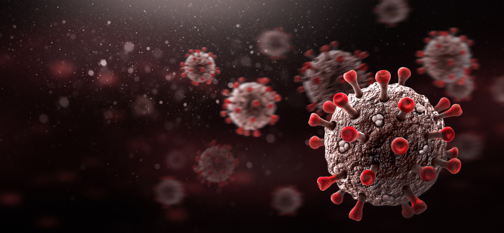

# Covid Analysis

**Objective** The main purpose of this project is to explore data provided from Covid worldwide. Through the project we will focus on using SQL and Python together to simulate a data exploration using SQLite, SQL Server or MySQL. At the end we will produce a dashboard on Tableau (which is presented at the beginning) using the tables built during the work. Despite the need to export the tables as CSV (because Tableau Public doesn't allow database connection) the overall projects objective is to go through the main SQL queries to achieve the information needed.

All the data used below was provided by the website: https://ourworldindata.org/covid-deaths

# Import libraries

```python
# Import libraries

import pandas as pd
import sqlite3 as sql
import os
from pprint import pprint

# Export libraries
from nbconvert.exporters import HTMLExporter
from nbconvert.preprocessors import TagRemovePreprocessor
from traitlets.config import Config
conf = Config()
conf.TagRemovePreprocessor.remove_input_tags = ('hide_code',)
conf.TagRemovePreprocessor.enabled = True
```

# Dashboard built

We will first present the dashboard built using some of the tables developed during the work below.

[figure not shown]

# Import data

In this work we will build a small database from ground using two different csv files. In industry cases the database could already be built and we would only need to access it. On other cases we could use MySQL to build the database along with the main view that we would need to access latter on the data analysis or model construction.

## Table 1 - Covid deaths

```python
# Import data with death information per country and date
death_tbl = pd.read_csv('data/CovidDeaths.csv', delimiter=';')

# Convert date to datetime type
death_tbl['date']= pd.to_datetime(death_tbl['date'], format= '%d/%m/%Y')

death_tbl.head()
```

|  | iso_code | continent | location | date | population | total_cases | new_cases | new_cases_smoothed | total_deaths | new_deaths | ... | new_deaths_smoothed_per_million | reproduction_rate | icu_patients | icu_patients_per_million | hosp_patients | hosp_patients_per_million | weekly_icu_admissions | weekly_icu_admissions_per_million | weekly_hosp_admissions | weekly_hosp_admissions_per_million |
| --- | --- | --- | --- | --- | --- | --- | --- | --- | --- | --- | --- | --- | --- | --- | --- | --- | --- | --- | --- | --- | --- |
| 0 | AFG | Asia | Afghanistan | 2020-02-24 | 40099462.0 | 5.0 | 5.0 | NaN | NaN | NaN | ... | NaN | NaN | NaN | NaN | NaN | NaN | NaN | NaN | NaN | NaN |
| 1 | AFG | Asia | Afghanistan | 2020-02-25 | 40099462.0 | 5.0 | 0.0 | NaN | NaN | NaN | ... | NaN | NaN | NaN | NaN | NaN | NaN | NaN | NaN | NaN | NaN |
| 2 | AFG | Asia | Afghanistan | 2020-02-26 | 40099462.0 | 5.0 | 0.0 | NaN | NaN | NaN | ... | NaN | NaN | NaN | NaN | NaN | NaN | NaN | NaN | NaN | NaN |
| 3 | AFG | Asia | Afghanistan | 2020-02-27 | 40099462.0 | 5.0 | 0.0 | NaN | NaN | NaN | ... | NaN | NaN | NaN | NaN | NaN | NaN | NaN | NaN | NaN | NaN |
| 4 | AFG | Asia | Afghanistan | 2020-02-28 | 40099462.0 | 5.0 | 0.0 | NaN | NaN | NaN | ... | NaN | NaN | NaN | NaN | NaN | NaN | NaN | NaN | NaN | NaN |

5 rows × 26 columns

## Table 1 - Covid vaccination

```python
# Import data with vacination information per country and date
vacci_tbl = pd.read_csv('data/CovidVaccinations.csv', delimiter=';')

# Convert date to datetime type
vacci_tbl['date']= pd.to_datetime(vacci_tbl['date'], format= '%d/%m/%Y')

vacci_tbl.head()
```

|  | iso_code | continent | location | date | total_tests | new_tests | total_tests_per_thousand | new_tests_per_thousand | new_tests_smoothed | new_tests_smoothed_per_thousand | ... | female_smokers | male_smokers | handwashing_facilities | hospital_beds_per_thousand | life_expectancy | human_development_index | excess_mortality_cumulative_absolute | excess_mortality_cumulative | excess_mortality | excess_mortality_cumulative_per_million |
| --- | --- | --- | --- | --- | --- | --- | --- | --- | --- | --- | --- | --- | --- | --- | --- | --- | --- | --- | --- | --- | --- |
| 0 | AFG | Asia | Afghanistan | 2020-02-24 | NaN | NaN | NaN | NaN | NaN | NaN | ... | NaN | NaN | 37.746 | 0.5 | 64.83 | 0.511 | NaN | NaN | NaN | NaN |
| 1 | AFG | Asia | Afghanistan | 2020-02-25 | NaN | NaN | NaN | NaN | NaN | NaN | ... | NaN | NaN | 37.746 | 0.5 | 64.83 | 0.511 | NaN | NaN | NaN | NaN |
| 2 | AFG | Asia | Afghanistan | 2020-02-26 | NaN | NaN | NaN | NaN | NaN | NaN | ... | NaN | NaN | 37.746 | 0.5 | 64.83 | 0.511 | NaN | NaN | NaN | NaN |
| 3 | AFG | Asia | Afghanistan | 2020-02-27 | NaN | NaN | NaN | NaN | NaN | NaN | ... | NaN | NaN | 37.746 | 0.5 | 64.83 | 0.511 | NaN | NaN | NaN | NaN |
| 4 | AFG | Asia | Afghanistan | 2020-02-28 | NaN | NaN | NaN | NaN | NaN | NaN | ... | NaN | NaN | 37.746 | 0.5 | 64.83 | 0.511 | NaN | NaN | NaN | NaN |

5 rows × 45 columns

# SQL database

The main purpose here is to build a data frame using the data imported from the .csv files. We could use both open-source **MySQL**/**SQL Server** or **SQLite**, it will depend on the work purpose.

**SQLite** is a server-less database and is self-contained. This is also referred to as an embedded database which means the DB engine runs as a part of the app.

On the other hand, **MySQL** requires a server to run. **MySQL** will require a client and server architecture to interact over a network.

Summarizing the options we can use **SQLite** when:

- Developing small standalone apps
- Smaller projects which do not require much scalability
- When you have a requirement to read and write directly from the disk
- Basic development and testing

  On the other hand we would requie a such as MySQL when:
- Multiple user access to apps
- When users require strong security and authentication features
- With distributed systems
- With apps requiring a larger database
- With projects which require more scalability
- Web-based applications
- When developing customized solutions

## Covid Deaths Table

```python
conn = sql.connect('covid')
c = conn.cursor()
```

```python
death_tbl.to_sql('CovidDeaths', conn, if_exists = 'replace', index = False)
```

```
217047
```

## Covid Vacination Table

```python
vacci_tbl.to_sql('CovidVaccinations', conn, if_exists = 'replace', index = False)
```

```
217047
```

Quality control to check if table were created

```python
res = c.execute("SELECT name FROM sqlite_master")
res.fetchall()
```

```
[('CovidDeaths',), ('CovidVaccinations',)]
```

We can see that the two table named **CovidDeaths** and **CovidVaccinations** were properly created.

# Data Exploration

```python
query = '''
SELECT location, date, total_cases, new_cases, total_deaths, population
FROM CovidDeaths
ORDER BY 1,2
LIMIT 20
'''
# We limited the output to 20 rows

c.execute(query)

res = c.fetchall()
```

In order to print our results we can use the **pprint** library which will make a pretty print of the requested data. However, if there is a lot of data, that can give a not so pretty table as expected. Consider for instance that we have limited our output to 20 rows.

```python
pprint(res)
```

```
[('Afghanistan', '2020-02-24 00:00:00', 5.0, 5.0, None, 40099462.0),
 ('Afghanistan', '2020-02-25 00:00:00', 5.0, 0.0, None, 40099462.0),
 ('Afghanistan', '2020-02-26 00:00:00', 5.0, 0.0, None, 40099462.0),
 ('Afghanistan', '2020-02-27 00:00:00', 5.0, 0.0, None, 40099462.0),
 ('Afghanistan', '2020-02-28 00:00:00', 5.0, 0.0, None, 40099462.0),
 ('Afghanistan', '2020-02-29 00:00:00', 5.0, 0.0, None, 40099462.0),
 ('Afghanistan', '2020-03-01 00:00:00', 5.0, 0.0, None, 40099462.0),
 ('Afghanistan', '2020-03-02 00:00:00', 5.0, 0.0, None, 40099462.0),
 ('Afghanistan', '2020-03-03 00:00:00', 5.0, 0.0, None, 40099462.0),
 ('Afghanistan', '2020-03-04 00:00:00', 5.0, 0.0, None, 40099462.0),
 ('Afghanistan', '2020-03-05 00:00:00', 5.0, 0.0, None, 40099462.0),
 ('Afghanistan', '2020-03-06 00:00:00', 5.0, 0.0, None, 40099462.0),
 ('Afghanistan', '2020-03-07 00:00:00', 8.0, 3.0, None, 40099462.0),
 ('Afghanistan', '2020-03-08 00:00:00', 8.0, 0.0, None, 40099462.0),
 ('Afghanistan', '2020-03-09 00:00:00', 8.0, 0.0, None, 40099462.0),
 ('Afghanistan', '2020-03-10 00:00:00', 8.0, 0.0, None, 40099462.0),
 ('Afghanistan', '2020-03-11 00:00:00', 11.0, 3.0, None, 40099462.0),
 ('Afghanistan', '2020-03-12 00:00:00', 11.0, 0.0, None, 40099462.0),
 ('Afghanistan', '2020-03-13 00:00:00', 11.0, 0.0, None, 40099462.0),
 ('Afghanistan', '2020-03-14 00:00:00', 14.0, 3.0, None, 40099462.0)]
```

Another option and better suited to present in this jupyter notebook is to convert the query to a pandas dataframe table in order improve our visualization.

```python
pd.read_sql_query(query, conn)
```

|  | location | date | total_cases | new_cases | total_deaths | population |
| --- | --- | --- | --- | --- | --- | --- |
| 0 | Afghanistan | 2020-02-24 00:00:00 | 5.0 | 5.0 | None | 40099462.0 |
| 1 | Afghanistan | 2020-02-25 00:00:00 | 5.0 | 0.0 | None | 40099462.0 |
| 2 | Afghanistan | 2020-02-26 00:00:00 | 5.0 | 0.0 | None | 40099462.0 |
| 3 | Afghanistan | 2020-02-27 00:00:00 | 5.0 | 0.0 | None | 40099462.0 |
| 4 | Afghanistan | 2020-02-28 00:00:00 | 5.0 | 0.0 | None | 40099462.0 |
| 5 | Afghanistan | 2020-02-29 00:00:00 | 5.0 | 0.0 | None | 40099462.0 |
| 6 | Afghanistan | 2020-03-01 00:00:00 | 5.0 | 0.0 | None | 40099462.0 |
| 7 | Afghanistan | 2020-03-02 00:00:00 | 5.0 | 0.0 | None | 40099462.0 |
| 8 | Afghanistan | 2020-03-03 00:00:00 | 5.0 | 0.0 | None | 40099462.0 |
| 9 | Afghanistan | 2020-03-04 00:00:00 | 5.0 | 0.0 | None | 40099462.0 |
| 10 | Afghanistan | 2020-03-05 00:00:00 | 5.0 | 0.0 | None | 40099462.0 |
| 11 | Afghanistan | 2020-03-06 00:00:00 | 5.0 | 0.0 | None | 40099462.0 |
| 12 | Afghanistan | 2020-03-07 00:00:00 | 8.0 | 3.0 | None | 40099462.0 |
| 13 | Afghanistan | 2020-03-08 00:00:00 | 8.0 | 0.0 | None | 40099462.0 |
| 14 | Afghanistan | 2020-03-09 00:00:00 | 8.0 | 0.0 | None | 40099462.0 |
| 15 | Afghanistan | 2020-03-10 00:00:00 | 8.0 | 0.0 | None | 40099462.0 |
| 16 | Afghanistan | 2020-03-11 00:00:00 | 11.0 | 3.0 | None | 40099462.0 |
| 17 | Afghanistan | 2020-03-12 00:00:00 | 11.0 | 0.0 | None | 40099462.0 |
| 18 | Afghanistan | 2020-03-13 00:00:00 | 11.0 | 0.0 | None | 40099462.0 |
| 19 | Afghanistan | 2020-03-14 00:00:00 | 14.0 | 3.0 | None | 40099462.0 |

Lets continue with the data exploration...

```python
# Total Cases Vs Total Deaths in Brazil
# Shows the percentages of cases that died after getting Covid throught time

query = """
SELECT location, date, total_cases, total_deaths, ROUND((total_deaths/total_cases)*100, 2) as DeathPercentage
FROM CovidDeaths
WHERE (location like 'Brazil' AND total_deaths IS NOT NULL)
ORDER BY 5
"""

pd.read_sql_query(query, conn)
```

|  | location | date | total_cases | total_deaths | DeathPercentage |
| --- | --- | --- | --- | --- | --- |
| 0 | Brazil | 2020-03-17 00:00:00 | 321.0 | 1.0 | 0.31 |
| 1 | Brazil | 2020-03-18 00:00:00 | 372.0 | 3.0 | 0.81 |
| 2 | Brazil | 2020-03-19 00:00:00 | 621.0 | 6.0 | 0.97 |
| 3 | Brazil | 2020-03-20 00:00:00 | 793.0 | 11.0 | 1.39 |
| 4 | Brazil | 2020-03-21 00:00:00 | 1021.0 | 15.0 | 1.47 |
| ... | ... | ... | ... | ... | ... |
| 909 | Brazil | 2020-04-28 00:00:00 | 73235.0 | 5083.0 | 6.94 |
| 910 | Brazil | 2020-05-01 00:00:00 | 92202.0 | 6412.0 | 6.95 |
| 911 | Brazil | 2020-05-02 00:00:00 | 97100.0 | 6761.0 | 6.96 |
| 912 | Brazil | 2020-05-13 00:00:00 | 190137.0 | 13240.0 | 6.96 |
| 913 | Brazil | 2020-05-12 00:00:00 | 178214.0 | 12461.0 | 6.99 |

914 rows × 5 columns

It can be seen that after the first Covid death in Brazil there we have in 914 day records. It is also stated that at the 4th day after the first death the death percentage was already 1.47, and that by **May 2020**, Brazil reached the **highest value 7% of death rate** from the total Covid Cases.

```python
# Total Cases Vs Population in Brazil
# Shows what percentage of the population got Covid

query = """
SELECT
    location,
    date,
    population,
    total_cases,
    ROUND((total_cases/population)*100, 2) as PercentPopulationInfected
FROM CovidDeaths
WHERE location like 'Brazil'
ORDER BY 1,2
"""

pd.read_sql_query(query, conn)
```

|  | location | date | population | total_cases | PercentPopulationInfected |
| --- | --- | --- | --- | --- | --- |
| 0 | Brazil | 2020-02-26 00:00:00 | 214326223.0 | 1.0 | 0.00 |
| 1 | Brazil | 2020-02-27 00:00:00 | 214326223.0 | 1.0 | 0.00 |
| 2 | Brazil | 2020-02-28 00:00:00 | 214326223.0 | 1.0 | 0.00 |
| 3 | Brazil | 2020-02-29 00:00:00 | 214326223.0 | 2.0 | 0.00 |
| 4 | Brazil | 2020-03-01 00:00:00 | 214326223.0 | 2.0 | 0.00 |
| ... | ... | ... | ... | ... | ... |
| 929 | Brazil | 2022-09-12 00:00:00 | 214326223.0 | 34533957.0 | 16.11 |
| 930 | Brazil | 2022-09-13 00:00:00 | 214326223.0 | 34544377.0 | 16.12 |
| 931 | Brazil | 2022-09-14 00:00:00 | 214326223.0 | 34558902.0 | 16.12 |
| 932 | Brazil | 2022-09-15 00:00:00 | 214326223.0 | 34568833.0 | 16.13 |
| 933 | Brazil | 2022-09-16 00:00:00 | 214326223.0 | 34568833.0 | 16.13 |

934 rows × 5 columns

Until 2022-09-16 approximately 16% of Brazilian population got Covid. Lets build the same data frame for each contry.

```python
# Total Cases Vs Population in Brazil
# Shows what percentage of the population got Covid

query = """
SELECT
    location,
    population,
    date,
    total_cases as HighestInfectionCount,
    ROUND((total_cases/population)*100, 2) as PercentPopulationInfected
FROM CovidDeaths
WHERE
    population is not null AND
    total_cases is not null
ORDER BY 1,2
"""

# We will be using this table on our table.
pd.read_sql_query(query, conn).to_csv('tableau_tbl/tbl4.csv', index = False, header = True, sep = ';', decimal = ',')

pd.read_sql_query(query, conn)
```

|  | location | population | date | HighestInfectionCount | PercentPopulationInfected |
| --- | --- | --- | --- | --- | --- |
| 0 | Afghanistan | 40099462.0 | 2020-02-24 00:00:00 | 5.0 | 0.00 |
| 1 | Afghanistan | 40099462.0 | 2020-02-25 00:00:00 | 5.0 | 0.00 |
| 2 | Afghanistan | 40099462.0 | 2020-02-26 00:00:00 | 5.0 | 0.00 |
| 3 | Afghanistan | 40099462.0 | 2020-02-27 00:00:00 | 5.0 | 0.00 |
| 4 | Afghanistan | 40099462.0 | 2020-02-28 00:00:00 | 5.0 | 0.00 |
| ... | ... | ... | ... | ... | ... |
| 207185 | Zimbabwe | 15993524.0 | 2022-09-12 00:00:00 | 256888.0 | 1.61 |
| 207186 | Zimbabwe | 15993524.0 | 2022-09-13 00:00:00 | 256904.0 | 1.61 |
| 207187 | Zimbabwe | 15993524.0 | 2022-09-14 00:00:00 | 256939.0 | 1.61 |
| 207188 | Zimbabwe | 15993524.0 | 2022-09-15 00:00:00 | 256939.0 | 1.61 |
| 207189 | Zimbabwe | 15993524.0 | 2022-09-16 00:00:00 | 256939.0 | 1.61 |

207190 rows × 5 columns

```python
# Looking at Countries with highest infection rate compared to population

query  = """
SELECT
    location,
    population,
    MAX(total_cases) as HighestInfectionCount,
    ROUND(MAX(total_cases/population)*100,2) as ContaminationPercentage
FROM CovidDeaths
WHERE
    continent is not null AND
    population is not null AND
    total_cases is not null
GROUP BY location
ORDER BY ContaminationPercentage DESC
"""

# We will be using this table on our table.
pd.read_sql_query(query, conn).to_csv('tableau_tbl/tbl3.csv', index = False, header = True, sep = ';', decimal = ',')

pd.read_sql_query(query, conn).head(20)
```

|  | location | population | HighestInfectionCount | ContaminationPercentage |
| --- | --- | --- | --- | --- |
| 0 | Faeroe Islands | 52888.0 | 34658.0 | 65.53 |
| 1 | Cyprus | 896007.0 | 582381.0 | 65.00 |
| 2 | Gibraltar | 32670.0 | 20069.0 | 61.43 |
| 3 | San Marino | 33746.0 | 20552.0 | 60.90 |
| 4 | Andorra | 79034.0 | 46147.0 | 58.39 |
| 5 | Austria | 8922082.0 | 5009501.0 | 56.15 |
| 6 | Denmark | 5854240.0 | 3285290.0 | 56.12 |
| 7 | Iceland | 370335.0 | 205284.0 | 55.43 |
| 8 | Slovenia | 2119410.0 | 1153964.0 | 54.45 |
| 9 | Saint Pierre and Miquelon | 5883.0 | 3166.0 | 53.82 |
| 10 | Portugal | 10290103.0 | 5456778.0 | 53.03 |
| 11 | France | 67422000.0 | 34922264.0 | 51.80 |
| 12 | Brunei | 445373.0 | 224610.0 | 50.43 |
| 13 | Falkland Islands | 3764.0 | 1886.0 | 50.11 |
| 14 | Israel | 9291000.0 | 4648673.0 | 50.03 |
| 15 | Liechtenstein | 39039.0 | 19419.0 | 49.74 |
| 16 | Latvia | 1873919.0 | 913371.0 | 48.74 |
| 17 | Netherlands | 17501696.0 | 8416314.0 | 48.09 |
| 18 | Slovakia | 5447622.0 | 2614999.0 | 48.00 |
| 19 | South Korea | 51830139.0 | 24359702.0 | 47.00 |

We can see that surprisingly there we countries with a high contamination rate reaching a **maximum of almost 66%**. Considering the data above, it can be seen that the top 5 countries with the highest rate have small population. However, countries such as **Austria**, **Denmark**, **Portugal**, **France**, etc. althought they have a considerable number of citizens the **contamination rate was higher than 50%**.

It is important to consider that the number of cases might be counted more than once for each individual, reason why, the effective percentage of population that got Covid should be less than calculated.

In order to efficiently calculated the contamination rate we should data related non repetitive contamination.

```python
# Showing countries with highes Death Count per Population

query = """
SELECT
    location,
    MAX(total_deaths) as TotalDeathCount
FROM CovidDeaths
WHERE continent is not null
GROUP BY location
ORDER BY TotalDeathCount DESC
"""

pd.read_sql_query(query, conn)
```

|  | location | TotalDeathCount |
| --- | --- | --- |
| 0 | United States | 1053389.0 |
| 1 | Brazil | 685203.0 |
| 2 | India | 528302.0 |
| 3 | Russia | 378029.0 |
| 4 | Mexico | 329767.0 |
| ... | ... | ... |
| 226 | Niue | NaN |
| 227 | Jersey | NaN |
| 228 | Guernsey | NaN |
| 229 | Guam | NaN |
| 230 | Falkland Islands | NaN |

231 rows × 2 columns

The country with the highest death count is United States, almost doubling the third place (India). Some of the countries didn't provide data related to the number of the counts, which is a more probable possibility than not having any deaths related to Covid.

```python
# Showing CONTINENT with highes Death Count per Population

query = """
SELECT
    continent,
    SUM(TotalDeathCount) as DeathsCount
FROM
(
    SELECT
        location,
        continent,
        MAX(total_deaths) as TotalDeathCount
    FROM CovidDeaths
    WHERE continent is not null
    GROUP BY location
    ORDER BY TotalDeathCount DESC
)
GROUP BY continent
ORDER BY DeathsCount DESC
"""

# We will be using this table on our table.
pd.read_sql_query(query, conn).to_csv('tableau_tbl/tbl2.csv', index = False, header = True, sep = ';', decimal = ',')

pd.read_sql_query(query, conn)
```

|  | continent | DeathsCount |
| --- | --- | --- |
| 0 | Europe | 1934866.0 |
| 1 | North America | 1505955.0 |
| 2 | Asia | 1480263.0 |
| 3 | South America | 1327476.0 |
| 4 | Africa | 256684.0 |
| 5 | Oceania | 19499.0 |

Europe was the continent high the highest number of deaths related to Covid while North America was the second one. From the North America we can see that United States was responsible for 2/3 of the death numbers.

```python
# GLOBAL NUMBERS - Global new cases and new deaths per day

query = """
SELECT
    date,
    SUM(new_cases) as new_cases,
    SUM(new_deaths) as new_deaths
FROM CovidDeaths
WHERE continent is not null
GROUP BY date
ORDER BY 1
"""

pd.read_sql_query(query, conn)
```

|  | date | new_cases | new_deaths |
| --- | --- | --- | --- |
| 0 | 2020-01-01 00:00:00 | NaN | NaN |
| 1 | 2020-01-02 00:00:00 | NaN | NaN |
| 2 | 2020-01-03 00:00:00 | NaN | NaN |
| 3 | 2020-01-04 00:00:00 | NaN | NaN |
| 4 | 2020-01-05 00:00:00 | NaN | NaN |
| ... | ... | ... | ... |
| 985 | 2022-09-12 00:00:00 | 507961.0 | 1477.0 |
| 986 | 2022-09-13 00:00:00 | 529233.0 | 1933.0 |
| 987 | 2022-09-14 00:00:00 | 703418.0 | 2459.0 |
| 988 | 2022-09-15 00:00:00 | 648260.0 | 2460.0 |
| 989 | 2022-09-16 00:00:00 | 455342.0 | 1986.0 |

990 rows × 3 columns

The table above presents the daily evolution of new cases and new deaths per day globally. This table can latter be used in tableau to build our dashboard.

```python
# GLOBAL NUMBERS - total cases, total deaths and death percentage by 2022-09-16

query = """
SELECT
    SUM(new_cases) as total_cases,
    SUM(new_deaths) as total_deaths,
    ROUND(
        SUM(new_deaths)*100/SUM(new_cases),
        2 )as DeathPerc
FROM CovidDeaths
WHERE continent is not null
"""

# We will be using this table on our table.
pd.read_sql_query(query, conn).to_csv('tableau_tbl/tbl1.csv', index = False, header = True, sep = ';', decimal = ',')

pd.read_sql_query(query, conn)
```

|  | total_cases | total_deaths | DeathPerc |
| --- | --- | --- | --- |
| 0 | 610255560.0 | 6486232.0 | 1.06 |

The table above presents the total number of cases, deaths and death percentage until 2022-09-16. It can be seen that almost 6.5 million people died and the global death rate is 1% from considering the total cases. The total amount of cases were 610 million.

# Join death and vaccionation tables

```python
# Total Population vs Vaccinations
# Shows Percentage of Population that has recieved at least one Covid Vaccine

query = """
SELECT
    dea.continent,
    dea.location,
    dea.date,
    dea.population,
    vac.new_vaccinations,
    SUM(vac.new_vaccinations) OVER (
        Partition by dea.location ORDER BY dea.location, dea.date) as RollingPeopleVaccinated
FROM CovidDeaths dea
JOIN CovidVaccinations vac
    ON dea.location = vac.location
    AND dea.date = vac.date
WHERE dea.continent is not null
order by 2,3
"""

pd.read_sql_query(query, conn)
```

|  | continent | location | date | population | new_vaccinations | RollingPeopleVaccinated |
| --- | --- | --- | --- | --- | --- | --- |
| 0 | Asia | Afghanistan | 2020-02-24 00:00:00 | 40099462.0 | NaN | NaN |
| 1 | Asia | Afghanistan | 2020-02-25 00:00:00 | 40099462.0 | NaN | NaN |
| 2 | Asia | Afghanistan | 2020-02-26 00:00:00 | 40099462.0 | NaN | NaN |
| 3 | Asia | Afghanistan | 2020-02-27 00:00:00 | 40099462.0 | NaN | NaN |
| 4 | Asia | Afghanistan | 2020-02-28 00:00:00 | 40099462.0 | NaN | NaN |
| ... | ... | ... | ... | ... | ... | ... |
| 204551 | Africa | Zimbabwe | 2022-09-12 00:00:00 | 15993524.0 | NaN | 10767732.0 |
| 204552 | Africa | Zimbabwe | 2022-09-13 00:00:00 | 15993524.0 | NaN | 10767732.0 |
| 204553 | Africa | Zimbabwe | 2022-09-14 00:00:00 | 15993524.0 | NaN | 10767732.0 |
| 204554 | Africa | Zimbabwe | 2022-09-15 00:00:00 | 15993524.0 | NaN | 10767732.0 |
| 204555 | Africa | Zimbabwe | 2022-09-16 00:00:00 | 15993524.0 | NaN | 10767732.0 |

204556 rows × 6 columns

Because we aren't able to check if the condition and calculations are ok, lets make a QC saving the result into a data frame. The QC will be done on two different countries.

```python
# QC
res = pd.read_sql_query(query, conn)
res[(res.location == 'Brazil') & (res.new_vaccinations.notnull())]
```

|  | continent | location | date | population | new_vaccinations | RollingPeopleVaccinated |
| --- | --- | --- | --- | --- | --- | --- |
| 25370 | South America | Brazil | 2021-01-18 00:00:00 | 214326223.0 | 997.0 | 997.0 |
| 25371 | South America | Brazil | 2021-01-19 00:00:00 | 214326223.0 | 12418.0 | 13415.0 |
| 25372 | South America | Brazil | 2021-01-20 00:00:00 | 214326223.0 | 92297.0 | 105712.0 |
| 25373 | South America | Brazil | 2021-01-21 00:00:00 | 214326223.0 | 87875.0 | 193587.0 |
| 25374 | South America | Brazil | 2021-01-22 00:00:00 | 214326223.0 | 268570.0 | 462157.0 |
| ... | ... | ... | ... | ... | ... | ... |
| 25972 | South America | Brazil | 2022-09-12 00:00:00 | 214326223.0 | 61105.0 | 450632990.0 |
| 25973 | South America | Brazil | 2022-09-13 00:00:00 | 214326223.0 | 112736.0 | 450745726.0 |
| 25974 | South America | Brazil | 2022-09-14 00:00:00 | 214326223.0 | 162244.0 | 450907970.0 |
| 25975 | South America | Brazil | 2022-09-15 00:00:00 | 214326223.0 | 96184.0 | 451004154.0 |
| 25976 | South America | Brazil | 2022-09-16 00:00:00 | 214326223.0 | 45944.0 | 451050098.0 |

539 rows × 6 columns

```python
res[(res.location == 'France') & (res.new_vaccinations.notnull())]
```

|  | continent | location | date | population | new_vaccinations | RollingPeopleVaccinated |
| --- | --- | --- | --- | --- | --- | --- |
| 64751 | Europe | France | 2020-12-28 00:00:00 | 67422000.0 | 684.0 | 684.0 |
| 64752 | Europe | France | 2020-12-29 00:00:00 | 67422000.0 | 384.0 | 1068.0 |
| 64753 | Europe | France | 2020-12-30 00:00:00 | 67422000.0 | 443.0 | 1511.0 |
| 64754 | Europe | France | 2020-12-31 00:00:00 | 67422000.0 | 441.0 | 1952.0 |
| 64755 | Europe | France | 2021-01-01 00:00:00 | 67422000.0 | 1160.0 | 3112.0 |
| ... | ... | ... | ... | ... | ... | ... |
| 65373 | Europe | France | 2022-09-11 00:00:00 | 67422000.0 | 1147.0 | 149617916.0 |
| 65374 | Europe | France | 2022-09-12 00:00:00 | 67422000.0 | 15986.0 | 149633902.0 |
| 65375 | Europe | France | 2022-09-13 00:00:00 | 67422000.0 | 30492.0 | 149664394.0 |
| 65376 | Europe | France | 2022-09-14 00:00:00 | 67422000.0 | 19464.0 | 149683858.0 |
| 65377 | Europe | France | 2022-09-15 00:00:00 | 67422000.0 | 26355.0 | 149710213.0 |

627 rows × 6 columns

The sum of vaccinated people through time is correct.

**END**

I hope you enjoyed it ! ;)